# Probabilidad y Estadística

Práctica Guiada

```r
library(tidyverse)
```

### Generación de datos aleatorios

Para generar datos aleatorios, usamos las funciones:

- `rnorm` para generar datos que surgen de una distribución normal
- `rt` para generar datos que surgen de una distribución T-student
- `rchisq` para generar datos que surgen de una distribución Chi cuadrado

> Pero antes, tenemos que fijar la *semilla* para que los datos sean reproducibles

```r
set.seed(1234)
rnorm(n = 15,mean = 0, sd = 1 )
```

```
 [1] -1.20706575  0.27742924  1.08444118 -2.34569770  0.42912469  0.50605589 -0.57473996
 [8] -0.54663186 -0.56445200 -0.89003783 -0.47719270 -0.99838644 -0.77625389  0.06445882
[15]  0.95949406
```

```r
rt(n = 15,df=1 )
```

```
 [1] -0.363717710 -1.603466805 -0.388596796 -0.588007490  0.007839245 14.690527710
 [7] -1.863488555  0.022667470 -2.084247299 -0.249237745 -1.311594174 -3.569055208
[13] -2.490838240 -3.848779244 -4.271087169
```

```r
rchisq(n = 15,df=1)
```

```
 [1] 0.5317744 1.4263809 4.2797098 0.2184660 0.6923773 0.0455256 3.1902100 0.2949942
 [9] 0.5403827 0.1543732 0.8639196 0.1417290 1.1386091 0.2966193 0.5110879
```

Para poder ver rápidamente de qué se tratan los valores, podemos usar el comando `plot`

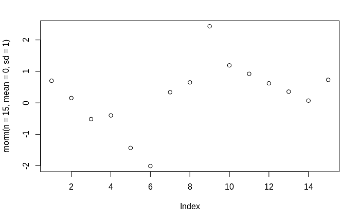

```r
plot(rnorm(n = 15, mean = 0, sd = 1 ))
```

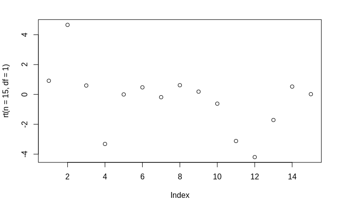

```r
plot(rt(n = 15, df=1 ))
```

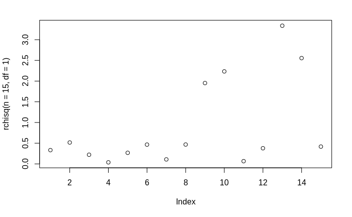

```r
plot(rchisq(n = 15,df=1))
```

Noten que el eje X es el índice de los valores, es decir que no agrega información.

### Tests

Utilicemos ahora datos reales.

Los datos salen de https://data.buenosaires.gob.ar/dataset/femicidios

> Vamos a ver ahora las estadisticas de Buenos Aires sobre la cantidad de femicidios por grupo etario. Es interesante preguntarse si hay más femicidios para cierto rango etario.

```r
femicidios <- read_csv(file = '../fuentes/vict_fem_annio__g_edad_limpio.csv')
femicidios
```

| anio | cantidad_femicidios | grupo_edad |
| --- | --- | --- |
| 2015 | 1 | 0 - 15 |
| 2015 | 2 | 16 - 20 |
| 2015 | 5 | 21 - 40 |
| 2015 | 3 | 41 - 60 |
| 2015 | - | 61 y más |
| 2015 | 1 | Ignorado |
| 2016 | 2 | 0 - 15 |
| 2016 | 3 | 16 - 20 |
| 2016 | 4 | 21 - 40 |
| 2016 | 1 | 41 - 60 |

[output cut: 9 more lines]

Fijense que las estadísitcas no están desagregadas por rango etario para 2017, que en caso de que haya 0 femicidios pusieron ‘-’ en lugar de 0. Además, como tenemos pocos datos, es mejor hacer un test que compare sólamente dos grupos.

Vamos a reorganizar la información para corregir todas estas cosas

```r
femicidios <- femicidios %>%
  filter(anio!=2017, grupo_edad !='Ignorado') %>%  #Sacamos al 2017 y los casos donde se ignora la edad
  mutate(cantidad_femicidios = case_when(cantidad_femicidios=='-' ~ 0, # reemplazamos el - por 0
                                         TRUE ~as.numeric(cantidad_femicidios)), # y convertimos la variable en numerica
         grupo_edad = case_when(grupo_edad %in% c('0 - 15','16 - 20','21 - 40') ~ '0-40', # agrupamos para tener sólo dos grupos
                                grupo_edad %in% c('41 - 60','61 y más') ~ '41 y más')) %>%
  group_by(grupo_edad) %>%
  summarise(cantidad_femicidios= sum(cantidad_femicidios)) # sumamos los años y grupos para tener datos agregados
```

```
NAs introduced by coercion
```

```r
femicidios
```

| grupo_edad | cantidad_femicidios |
| --- | --- |
| 0-40 | 17 |
| 41 y más | 6 |

Con esta tabla de contingencia podemos hacer un test de hipótesis.

¿Cuál usamos? Nos fijamos en el machete, o googleamos, y vemos que como queremos comparar la cantidad de casos por grupos categóricos, tenemos que usar el test Chi.

- $H_0$ No hay asociación entre las variables
- $H_1$ Hay asociación entre las variables

La idea es que tenemos dos variables: El rango etario y la cantidad de femicidios

```r
chisq.test(femicidios$cantidad_femicidios)
```

```
    Chi-squared test for given probabilities

data:  femicidios$cantidad_femicidios
X-squared = 5.2609, df = 1, p-value = 0.02181
```

Noten que el resultado lo dan en términos del p-valor. Como el valor es bajo, menor a 0.05, entonces podemos rechazar que no existe relación. O en otros términos, pareciera que la diferencia es significativa estadísticamente.

### Descripción estadística de los datos

Volveremos a ver los datos de [sueldos de funcionarios](https://data.buenosaires.gob.ar/dataset/sueldo-funcionarios)

```r
sueldos <- read_csv('../fuentes/sueldo_funcionarios_2019.csv')
```

Con el comando `summary` podemos ver algunos de los principales estadísticos de resumen

```r
summary(sueldos$asignacion_por_cargo_i)
```

```
   Min. 1st Qu.  Median    Mean 3rd Qu.    Max.
 197746  210061  226866  225401  231168  249662
```

### Gráficos estadísticos

No nos vamos a detener demasiado a ver cómo hacer los gráficos de resumen, porque la próxima clase veremos como realizar gráficos de mejor calidad, como los presentados en las notas de clase.

A modo de ejemplo, dejamos los comandos de R base para realizar gráficos.

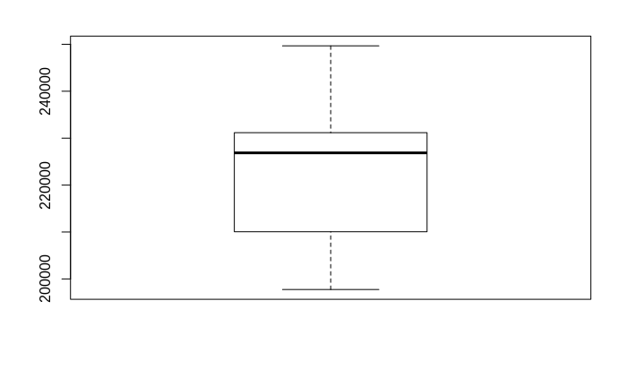

```r
boxplot(sueldos$asignacion_por_cargo_i)
```

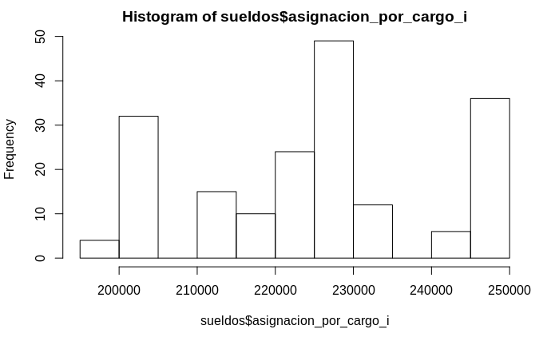

```r
hist(sueldos$asignacion_por_cargo_i)
```

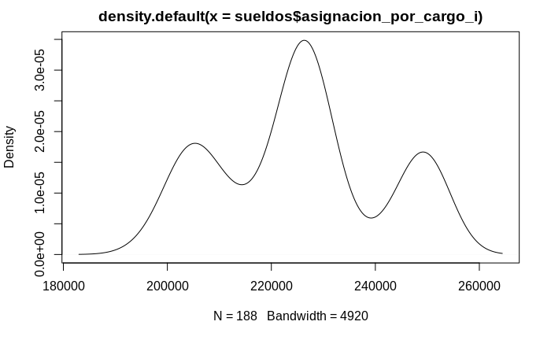

```r
plot(density(sueldos$asignacion_por_cargo_i))
```